## **“Predict the manner in which they did the exercise.”**

Author: “Lex Knape” Date: Thursday 18 june 2015 Software: OSX Yosemite 10.10.3, RStudio Version 0.98.1091 job: Manager data Science Renault subtitle: Course project part of Lesson 8 Machine learning. Hardware: MacBook Pro, processor 2.4 GHz Intel dual-Core i5, Memory 8 GB 1067 MHz DDR3

## **Project description**

Using devices such as Jawbone Up, Nike FuelBand, and Fitbit it is now possible to collect a large amount of data about personal activity relatively inexpensively. These type of devices are part of the quantified self movement ??? a group of enthusiasts who take measurements about themselves regularly to improve their health, to find patterns in their behavior, or because they are tech geeks. One thing that people regularly do is quantify how much of a particular activity they do, but they rarely quantify how well they do it. In this project, your goal will be to use data from accelerometers on the belt, forearm, arm, and dumbell of 6 participants. They were asked to perform barbell lifts correctly and incorrectly in 5 different ways. More information is available from the website here: http://groupware.les.inf.puc-rio.br/har (see the section on the Weight Lifting Exercise Dataset).

The six young health participants were asked to perform one set of 10 repetitions of the Unilateral Dumbbell Biceps Curl in five different fashions: exactly according to the specification (Class A), throwing the elbows to the front (Class B), lifting the dumbbell only halfway (Class C), lowering the dumbbell only halfway (Class D) and throwing the hips to the front (Class E).

Class A corresponds to the specified execution of the exercise, while the other 4 classes correspond to common mistakes. Participants were supervised by an experienced weight lifter to make sure the execution complied to the manner they were supposed to simulate. The exercises were performed by six male participants aged between 20-28 years, with little weight lifting experience. We made sure that all participants could easily simulate the mistakes in a safe and controlled manner by using a relatively light dumbbell (1.25kg).

The test data are available here: https://d396qusza40orc.cloudfront.net/predmachlearn/pml-testing.csv

The data for this project come from this source: http://groupware.les.inf.puc-rio.br/har. If you use the document you create for this class for any purpose please cite them as they have been very generous in allowing their data to be used for this kind of assignment.

### **What you should submit**

The goal of your project is to predict the manner in which they did the exercise. This is the “classe” variable in the training set. You may use any of the other variables to predict with. You should create a report describing 1. how you built your model, 2. how you used cross validation, 3. what you think the expected out of sample error is, 4. why you made the choices you did. 5. you will also use your prediction model to predict 20 different test cases.

1. Your submission should consist of a link to a Github repo with your R markdown and compiled HTML file describing your analysis. Please constrain the text of the writeup to < 2000 words and the number of figures to be less than 5. It will make it easier for the graders if you submit a repo with a gh-pages branch so the HTML page can be viewed online (and you always want to make it easy on graders :-).
2. You should also apply your machine learning algorithm to the 20 test cases available in the test data above. Please submit your predictions in appropriate format to the programming assignment for automated grading. See the programming assignment for additional details.

### **How you built your model**

Our outcome variable is classe, a factor variable. For this data set, 6 participants were asked to perform one set of 10 repetitions of the Unilateral Dumbbell Biceps Curl in 5 different fashions: - exactly according to the specification (Class A) - throwing the elbows to the front (Class B) - lifting the dumbbell only halfway (Class C) - lowering the dumbbell only halfway (Class D) - throwing the hips to the front (Class E)

After setting the workdirectory, I installed the packages and loaded the libraries. I downloaded the data and created both training and test set. In order to get a feel of the dataset I explored the data via the str (to many variables to use the summary function) and also via the dim, View , head and tail function.

After exploring the data I recognized that the data has been drawn under highly controlled conditions. This explains the low percentage of segregated training data. I cleaned the data from variables containing only NA’s and variables with values near Zero. I also removed variables with no added value to the predictions like timestamps etc.

I then split the Trainingset into a dataset for building the model and into a set for cross validation. As a rule of thumb for prediction study design for medium sample sizes I split the Trainingset in 60% training and 40% testing.

I built the various models using the train function of the Caret package. I choosed Two models will be tested using decision tree and random forest. The model with the highest accuracy will be chosen as our final model. In the sections How I used cross validation aI added also info about how you built my model

### **How I used cross validation**

Cross-validation, sometimes called rotation estimation, is a model validation technique for assessing how the results of a statistical analysis will generalize to an independent data set. With cross validation I want to estimate how accurately a predictive model will perform in practice. In this project a model is given a training dataset on which training is run, and a dataset against which the model is tested, the testing dataset. Thus the goal of cross validation is to define a dataset to “test” the model in the training phase (i.e., the validation dataset), in order to limit problems like overfitting, give an insight on how the model will generalize to an independent dataset. The rules of thumb for prediction study design for medium sample size is split the Trainingset in 60% training and 40% testing which is what I have done.

One round of cross-validation involves partitioning a sample of data into complementary subsets, performing the analysis on one subset (called the training set), and validating the analysis on the other subset (called the validation set or testing set). To reduce variability, multiple rounds of cross-validation are performed using different partitions, and the validation results are averaged over the rounds.

### **why you made the choices you did.**

As I do a lot of programming in my work I never build a machine learning model so I followed the instructions from the lecture and discussion forum in order not to loose too much time and stick to basics to get the results in time. FYI a lost two days due to having the used the trainingset for both training and final testset. I choose the 60% trainingset as I dealt with a medium set and did the NearZeroVar, NA cleanup and removed the first variables as they had no added value. I still find it difficult which model I must choose and is defintely a focus for the near future. I therefor sticked to the decision tree and Random forest well known to have the best results in machine learning and it worked.

## **Conclusion**

I found it very interesting to go through a serious Machine learning example and saw the general steps necessary to create training and testset, choose a model and see by the outcome which one is the best and apply the model on the test ste to predict the classe. I choose the Random Forest model as it showed the best accuracy and the results of the predicted showed an ultimate score with congratulations on all 20 cases.

### **Loading and preprocessing the data**

I always start with setting the working directory and I checked if it existed.

```r
setwd("/Users/anknape/Mainfolder/Study/Coursera/Data Science/Les 8 Machine Learning")
getwd()
```

```
## [1] "/Users/anknape/Mainfolder/Study/Coursera/Data Science/Les 8 Machine Learning"
```

I installed the required packages and load the libraries

```r
# install.packages("caret")
# install.packages("randomForest")
# install.packages("ggplot2")
# install.packages("lattice")

library(caret)
library(randomForest)
library(ggplot2)
library(lattice)
```

I set.seed as I want reproducible results.

```r
set.seed(12345)
```

I set variables for the Trainurl and Testurl

```r
Trainurl <- "http://d396qusza40orc.cloudfront.net/predmachlearn/pml-training.csv"
Testurl <- "http://d396qusza40orc.cloudfront.net/predmachlearn/pml-testing.csv"
```

The data is downloaded and to the working directory and is set in vectors trainingset and testset

```r
download.file(Trainurl,"pml-training.csv")
trainingset <- read.csv("pml-training.csv", na.strings=c("NA","#DIV/0!", ""))
download.file(Testurl,"pml-testing.csv")
testset <- read.csv("pml-testing.csv", na.strings=c("NA","#DIV/0!", ""))
```

I performed some exploratory analysis with dim, View, str, head and tail

```r
dim(trainingset)
```

```
## [1] 19622   160
```

```r
View(trainingset)
str(trainingset)
```

```
## 'data.frame':    19622 obs. of  160 variables:
##  $ X                       : int  1 2 3 4 5 6 7 8 9 10 ...
##  $ user_name               : Factor w/ 6 levels "adelmo","carlitos",..: 2 2 2 2 2 2 2 2 2 2 ...
##  $ raw_timestamp_part_1    : int  1323084231 1323084231 1323084231 1323084232 1323084232 1323084232 1323084232 1323084232 1323084232 1323084232 ...
##  $ raw_timestamp_part_2    : int  788290 808298 820366 120339 196328 304277 368296 440390 484323 484434 ...
##  $ cvtd_timestamp          : Factor w/ 20 levels "02/12/2011 13:32",..: 9 9 9 9 9 9 9 9 9 9 ...
##  $ new_window              : Factor w/ 2 levels "no","yes": 1 1 1 1 1 1 1 1 1 1 ...
##  $ num_window              : int  11 11 11 12 12 12 12 12 12 12 ...
##  $ roll_belt               : num  1.41 1.41 1.42 1.48 1.48 1.45 1.42 1.42 1.43 1.45 ...
##  $ pitch_belt              : num  8.07 8.07 8.07 8.05 8.07 8.06 8.09 8.13 8.16 8.17 ...
##  $ yaw_belt                : num  -94.4 -94.4 -94.4 -94.4 -94.4 -94.4 -94.4 -94.4 -94.4 -94.4 ...
##  $ total_accel_belt        : int  3 3 3 3 3 3 3 3 3 3 ...
##  $ kurtosis_roll_belt      : num  NA NA NA NA NA NA NA NA NA NA ...
##  $ kurtosis_picth_belt     : num  NA NA NA NA NA NA NA NA NA NA ...
##  $ kurtosis_yaw_belt       : logi  NA NA NA NA NA NA ...
```

[output cut: 86 more lines]

```r
head(trainingset)
```

```
##   X user_name raw_timestamp_part_1 raw_timestamp_part_2   cvtd_timestamp
## 1 1  carlitos           1323084231               788290 05/12/2011 11:23
## 2 2  carlitos           1323084231               808298 05/12/2011 11:23
## 3 3  carlitos           1323084231               820366 05/12/2011 11:23
## 4 4  carlitos           1323084232               120339 05/12/2011 11:23
## 5 5  carlitos           1323084232               196328 05/12/2011 11:23
## 6 6  carlitos           1323084232               304277 05/12/2011 11:23
##   new_window num_window roll_belt pitch_belt yaw_belt total_accel_belt
## 1         no         11      1.41       8.07    -94.4                3
## 2         no         11      1.41       8.07    -94.4                3
## 3         no         11      1.42       8.07    -94.4                3
## 4         no         12      1.48       8.05    -94.4                3
## 5         no         12      1.48       8.07    -94.4                3
## 6         no         12      1.45       8.06    -94.4                3
##   kurtosis_roll_belt kurtosis_picth_belt kurtosis_yaw_belt
```

[output cut: 265 more lines]

```r
tail(trainingset)
```

```
##           X user_name raw_timestamp_part_1 raw_timestamp_part_2
## 19617 19617    adelmo           1322832937               588324
## 19618 19618    adelmo           1322832937               588376
## 19619 19619    adelmo           1322832937               596287
## 19620 19620    adelmo           1322832937               636283
## 19621 19621    adelmo           1322832937               964299
## 19622 19622    adelmo           1322832937               972293
##         cvtd_timestamp new_window num_window roll_belt pitch_belt yaw_belt
## 19617 02/12/2011 13:35         no        864       148      -34.7      129
## 19618 02/12/2011 13:35         no        864       147      -34.8      129
## 19619 02/12/2011 13:35         no        864       145      -35.3      130
## 19620 02/12/2011 13:35         no        864       145      -35.5      130
## 19621 02/12/2011 13:35         no        864       143      -35.9      131
## 19622 02/12/2011 13:35        yes        864       143      -36.0      132
##       total_accel_belt kurtosis_roll_belt kurtosis_picth_belt
```

[output cut: 286 more lines]

I checked the influence of the NA’s on the trainingset via the table function.

```r
table(is.na(trainingset))
```

```
##
##   FALSE    TRUE
## 1214418 1925102
```

I checked which variables had value near zero and could be removed as the influence as predictor is near zero.

```r
TrainingNSV <- nearZeroVar(trainingset,saveMetrics=TRUE)
TrainingNSV
```

```
##                          freqRatio percentUnique zeroVar   nzv
## X                         1.000000  100.00000000   FALSE FALSE
## user_name                 1.100679    0.03057792   FALSE FALSE
## raw_timestamp_part_1      1.000000    4.26562022   FALSE FALSE
## raw_timestamp_part_2      1.000000   85.53154622   FALSE FALSE
## cvtd_timestamp            1.000668    0.10192641   FALSE FALSE
## new_window               47.330049    0.01019264   FALSE  TRUE
## num_window                1.000000    4.37264295   FALSE FALSE
## roll_belt                 1.101904    6.77810621   FALSE FALSE
## pitch_belt                1.036082    9.37722964   FALSE FALSE
## yaw_belt                  1.058480    9.97349913   FALSE FALSE
## total_accel_belt          1.063160    0.14779329   FALSE FALSE
## kurtosis_roll_belt        2.000000    2.01304658   FALSE FALSE
## kurtosis_picth_belt       1.333333    1.60534094   FALSE FALSE
## kurtosis_yaw_belt         0.000000    0.00000000    TRUE  TRUE
## skewness_roll_belt        2.000000    2.00285394   FALSE FALSE
## skewness_roll_belt.1      1.333333    1.71236367   FALSE FALSE
## skewness_yaw_belt         0.000000    0.00000000    TRUE  TRUE
## max_roll_belt             1.000000    0.99378249   FALSE FALSE
## max_picth_belt            1.538462    0.11211905   FALSE FALSE
## max_yaw_belt              1.034483    0.33635715   FALSE FALSE
## min_roll_belt             1.000000    0.93772296   FALSE FALSE
## min_pitch_belt            2.192308    0.08154113   FALSE FALSE
## min_yaw_belt              1.034483    0.33635715   FALSE FALSE
## amplitude_roll_belt       1.290323    0.75425543   FALSE FALSE
## amplitude_pitch_belt      3.042254    0.06625217   FALSE FALSE
## amplitude_yaw_belt        0.000000    0.00509632    TRUE  TRUE
## var_total_accel_belt      1.426829    0.33126083   FALSE FALSE
## avg_roll_belt             1.066667    0.97339721   FALSE FALSE
## stddev_roll_belt          1.039216    0.35164611   FALSE FALSE
## var_roll_belt             1.615385    0.48924676   FALSE FALSE
## avg_pitch_belt            1.375000    1.09061258   FALSE FALSE
## stddev_pitch_belt         1.161290    0.21914178   FALSE FALSE
## var_pitch_belt            1.307692    0.32106819   FALSE FALSE
## avg_yaw_belt              1.200000    1.22311691   FALSE FALSE
## stddev_yaw_belt           1.693878    0.29558659   FALSE FALSE
## var_yaw_belt              1.500000    0.73896647   FALSE FALSE
## gyros_belt_x              1.058651    0.71348486   FALSE FALSE
## gyros_belt_y              1.144000    0.35164611   FALSE FALSE
## gyros_belt_z              1.066214    0.86127816   FALSE FALSE
```

[output cut: 106 more lines]

```
## stddev_pitch_forearm     41.500000    1.64611151   FALSE  TRUE
## var_pitch_forearm        83.000000    1.65120783   FALSE  TRUE
## avg_yaw_forearm          83.000000    1.65120783   FALSE  TRUE
## stddev_yaw_forearm       85.000000    1.64101519   FALSE  TRUE
## var_yaw_forearm          85.000000    1.64101519   FALSE  TRUE
## gyros_forearm_x           1.059273    1.51870350   FALSE FALSE
## gyros_forearm_y           1.036554    3.77637346   FALSE FALSE
## gyros_forearm_z           1.122917    1.56457038   FALSE FALSE
## accel_forearm_x           1.126437    4.04647844   FALSE FALSE
## accel_forearm_y           1.059406    5.11160942   FALSE FALSE
## accel_forearm_z           1.006250    2.95586586   FALSE FALSE
## magnet_forearm_x          1.012346    7.76679238   FALSE FALSE
## magnet_forearm_y          1.246914    9.54031189   FALSE FALSE
## magnet_forearm_z          1.000000    8.57710733   FALSE FALSE
## classe                    1.469581    0.02548160   FALSE FALSE
```

```r
TestNSV <- nearZeroVar(testset,saveMetrics=TRUE)
TestNSV
```

```
##                          freqRatio percentUnique zeroVar   nzv
## X                         1.000000           100   FALSE FALSE
## user_name                 2.000000            30   FALSE FALSE
## raw_timestamp_part_1      1.000000           100   FALSE FALSE
## raw_timestamp_part_2      1.000000           100   FALSE FALSE
## cvtd_timestamp            1.333333            55   FALSE FALSE
## new_window                0.000000             5    TRUE  TRUE
## num_window                1.000000           100   FALSE FALSE
## roll_belt                 1.000000            90   FALSE FALSE
## pitch_belt                1.000000           100   FALSE FALSE
## yaw_belt                  1.000000            90   FALSE FALSE
## total_accel_belt          1.200000            45   FALSE FALSE
## kurtosis_roll_belt        0.000000             0    TRUE  TRUE
## kurtosis_picth_belt       0.000000             0    TRUE  TRUE
## kurtosis_yaw_belt         0.000000             0    TRUE  TRUE
## skewness_roll_belt        0.000000             0    TRUE  TRUE
## skewness_roll_belt.1      0.000000             0    TRUE  TRUE
## skewness_yaw_belt         0.000000             0    TRUE  TRUE
## max_roll_belt             0.000000             0    TRUE  TRUE
## max_picth_belt            0.000000             0    TRUE  TRUE
## max_yaw_belt              0.000000             0    TRUE  TRUE
## min_roll_belt             0.000000             0    TRUE  TRUE
## min_pitch_belt            0.000000             0    TRUE  TRUE
## min_yaw_belt              0.000000             0    TRUE  TRUE
## amplitude_roll_belt       0.000000             0    TRUE  TRUE
## amplitude_pitch_belt      0.000000             0    TRUE  TRUE
## amplitude_yaw_belt        0.000000             0    TRUE  TRUE
## var_total_accel_belt      0.000000             0    TRUE  TRUE
## avg_roll_belt             0.000000             0    TRUE  TRUE
## stddev_roll_belt          0.000000             0    TRUE  TRUE
## var_roll_belt             0.000000             0    TRUE  TRUE
## avg_pitch_belt            0.000000             0    TRUE  TRUE
## stddev_pitch_belt         0.000000             0    TRUE  TRUE
## var_pitch_belt            0.000000             0    TRUE  TRUE
## avg_yaw_belt              0.000000             0    TRUE  TRUE
## stddev_yaw_belt           0.000000             0    TRUE  TRUE
## var_yaw_belt              0.000000             0    TRUE  TRUE
## gyros_belt_x              1.500000            70   FALSE FALSE
## gyros_belt_y              2.250000            30   FALSE FALSE
## gyros_belt_z              2.500000            65   FALSE FALSE
```

[output cut: 106 more lines]

```
## stddev_pitch_forearm      0.000000             0    TRUE  TRUE
## var_pitch_forearm         0.000000             0    TRUE  TRUE
## avg_yaw_forearm           0.000000             0    TRUE  TRUE
## stddev_yaw_forearm        0.000000             0    TRUE  TRUE
## var_yaw_forearm           0.000000             0    TRUE  TRUE
## gyros_forearm_x           1.000000            90   FALSE FALSE
## gyros_forearm_y           1.000000           100   FALSE FALSE
## gyros_forearm_z           1.000000           100   FALSE FALSE
## accel_forearm_x           1.000000           100   FALSE FALSE
## accel_forearm_y           1.000000           100   FALSE FALSE
## accel_forearm_z           1.000000           100   FALSE FALSE
## magnet_forearm_x          1.000000           100   FALSE FALSE
## magnet_forearm_y          1.000000           100   FALSE FALSE
## magnet_forearm_z          1.000000           100   FALSE FALSE
## problem_id                1.000000           100   FALSE FALSE
```

I removed the variables indicated by the TrainingNSV and TestNSV

```r
trainingset <- trainingset[,-nearZeroVar(trainingset)]
testset <- testset[,-nearZeroVar(testset)]
names(trainingset)
```

```
##   [1] "X"                        "user_name"
##   [3] "raw_timestamp_part_1"     "raw_timestamp_part_2"
##   [5] "cvtd_timestamp"           "num_window"
##   [7] "roll_belt"                "pitch_belt"
##   [9] "yaw_belt"                 "total_accel_belt"
##  [11] "kurtosis_roll_belt"       "kurtosis_picth_belt"
##  [13] "skewness_roll_belt"       "skewness_roll_belt.1"
##  [15] "max_roll_belt"            "max_picth_belt"
##  [17] "max_yaw_belt"             "min_roll_belt"
##  [19] "min_pitch_belt"           "min_yaw_belt"
##  [21] "amplitude_roll_belt"      "amplitude_pitch_belt"
##  [23] "var_total_accel_belt"     "avg_roll_belt"
##  [25] "stddev_roll_belt"         "var_roll_belt"
##  [27] "avg_pitch_belt"           "stddev_pitch_belt"
##  [29] "var_pitch_belt"           "avg_yaw_belt"
```

[output cut: 47 more lines]

I removed the variables with only NA as they have no value as predictor and checked the vectors after the cleaning with the exploitory functions; View and str

```r
trainingset <- trainingset[,colSums(is.na(trainingset)) == 0]
testset <- testset[,colSums(is.na(testset)) == 0]

View(trainingset)
str(trainingset)
```

```
## 'data.frame':    19622 obs. of  59 variables:
##  $ X                   : int  1 2 3 4 5 6 7 8 9 10 ...
##  $ user_name           : Factor w/ 6 levels "adelmo","carlitos",..: 2 2 2 2 2 2 2 2 2 2 ...
##  $ raw_timestamp_part_1: int  1323084231 1323084231 1323084231 1323084232 1323084232 1323084232 1323084232 1323084232 1323084232 1323084232 ...
##  $ raw_timestamp_part_2: int  788290 808298 820366 120339 196328 304277 368296 440390 484323 484434 ...
##  $ cvtd_timestamp      : Factor w/ 20 levels "02/12/2011 13:32",..: 9 9 9 9 9 9 9 9 9 9 ...
##  $ num_window          : int  11 11 11 12 12 12 12 12 12 12 ...
##  $ roll_belt           : num  1.41 1.41 1.42 1.48 1.48 1.45 1.42 1.42 1.43 1.45 ...
##  $ pitch_belt          : num  8.07 8.07 8.07 8.05 8.07 8.06 8.09 8.13 8.16 8.17 ...
##  $ yaw_belt            : num  -94.4 -94.4 -94.4 -94.4 -94.4 -94.4 -94.4 -94.4 -94.4 -94.4 ...
##  $ total_accel_belt    : int  3 3 3 3 3 3 3 3 3 3 ...
##  $ gyros_belt_x        : num  0 0.02 0 0.02 0.02 0.02 0.02 0.02 0.02 0.03 ...
##  $ gyros_belt_y        : num  0 0 0 0 0.02 0 0 0 0 0 ...
##  $ gyros_belt_z        : num  -0.02 -0.02 -0.02 -0.03 -0.02 -0.02 -0.02 -0.02 -0.02 0 ...
##  $ accel_belt_x        : int  -21 -22 -20 -22 -21 -21 -22 -22 -20 -21 ...
```

[output cut: 45 more lines]

```r
trainingset   <-trainingset[,-c(1:6)]
testset   <-testset[,-c(1:6)]
```

The rules of thumb for prediction study design for medium sample size is split the Trainingset in 60% training and 40% testing.

```r
Trainset <- createDataPartition(y=trainingset$classe, p=0.6, list=FALSE)
TrainSet <- trainingset[Trainset, ]
TestSet <- trainingset[-Trainset, ]
```

I plotted the trainingset to see the different levels and frequency of the classe.

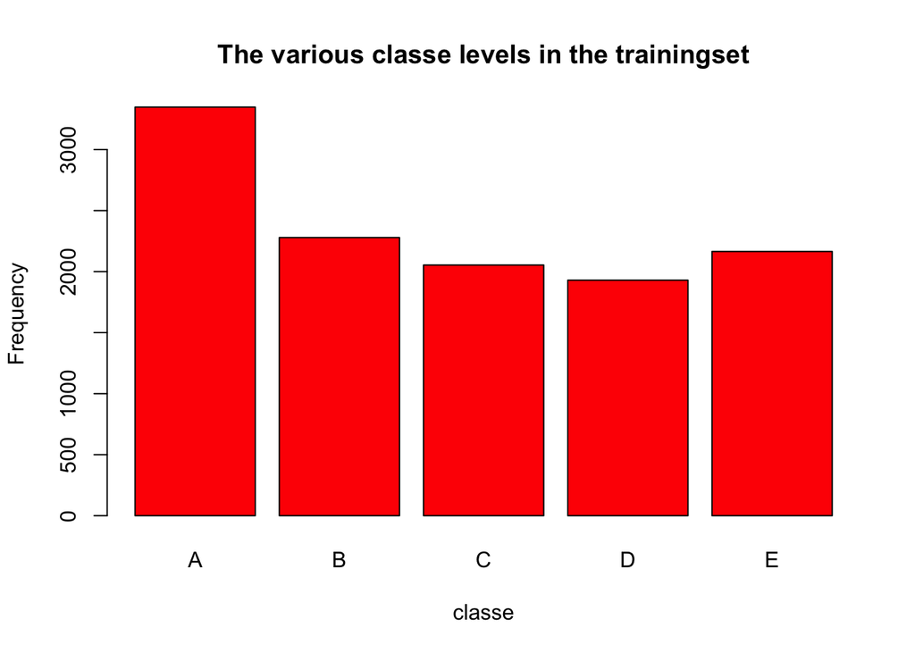

```r
plot(TrainSet$classe, col="red", main="The various classe levels in the trainingset", xlab="classe", ylab="Frequency")
```

I included in the extra options in train function instead of using the standard train function as described above.

```r
tc <- trainControl(method = "cv", number = 7, verboseIter=FALSE , preProcOptions="pca", allowParallel=TRUE)
tc
```

[output not shown]

[output cut: 30 more lines]

```
## $adaptive$alpha
## [1] 0.05
##
## $adaptive$method
## [1] "gls"
##
## $adaptive$complete
## [1] TRUE
##
##
## $trim
## [1] FALSE
##
## $allowParallel
## [1] TRUE
```

I selected two models 1. The Decision tree and the 2. Random forect model. First I build the Ctree model, did a prediction on the testset and got the results via the confusionmatrix. I used the traincontrol in the trainingset.

```r
ModelFitDT <- train(classe ~ ., data = TrainSet, method = "ctree", trControl = tc)
ModelFitDT
```

```
## Conditional Inference Tree
##
## 11776 samples
##    52 predictor
##     5 classes: 'A', 'B', 'C', 'D', 'E'
##
## No pre-processing
## Resampling: Cross-Validated (7 fold)
##
## Summary of sample sizes: 10092, 10093, 10094, 10093, 10094, 10095, ...
##
## Resampling results across tuning parameters:
##
##   mincriterion  Accuracy   Kappa      Accuracy SD  Kappa SD
##   0.01          0.8712611  0.8371525  0.009956853  0.01266464
##   0.50          0.8703268  0.8359575  0.009950558  0.01265766
##   0.99          0.8600520  0.8229853  0.010327039  0.01311572
##
## Accuracy was used to select the optimal model using  the largest value.
## The final value used for the model was mincriterion = 0.01.
```

```r
prediction1 <- predict(ModelFitDT, newdata = TestSet)
confusionMatrix(prediction1, TestSet$classe)
```

```
## Confusion Matrix and Statistics
##
##           Reference
## Prediction    A    B    C    D    E
##          A 2104   91   19   34   21
##          B   63 1292   77   53   48
##          C   24   51 1195   49   20
##          D   21   35   56 1105   40
##          E   20   49   21   45 1313
##
## Overall Statistics
##
##                Accuracy : 0.8933
##                  95% CI : (0.8863, 0.9001)
##     No Information Rate : 0.2845
##     P-Value [Acc > NIR] : < 2e-16
##
##                   Kappa : 0.865
##  Mcnemar's Test P-Value : 0.04668
##
## Statistics by Class:
##
##                      Class: A Class: B Class: C Class: D Class: E
## Sensitivity            0.9427   0.8511   0.8735   0.8593   0.9105
## Specificity            0.9706   0.9619   0.9778   0.9768   0.9789
## Pos Pred Value         0.9273   0.8428   0.8925   0.8791   0.9068
## Neg Pred Value         0.9770   0.9642   0.9734   0.9725   0.9798
## Prevalence             0.2845   0.1935   0.1744   0.1639   0.1838
## Detection Rate         0.2682   0.1647   0.1523   0.1408   0.1673
## Detection Prevalence   0.2892   0.1954   0.1707   0.1602   0.1846
## Balanced Accuracy      0.9566   0.9065   0.9257   0.9180   0.9447
```

I did the same for the RandomForest model

```r
ModelFitRF <- train(classe ~ ., data = TrainSet, method = "rf", trControl = tc)
ModelFitRF
```

```
## Random Forest
##
## 11776 samples
##    52 predictor
##     5 classes: 'A', 'B', 'C', 'D', 'E'
##
## No pre-processing
## Resampling: Cross-Validated (7 fold)
##
## Summary of sample sizes: 10092, 10093, 10096, 10094, 10094, 10093, ...
##
## Resampling results across tuning parameters:
##
##   mtry  Accuracy   Kappa      Accuracy SD  Kappa SD
##    2    0.9892164  0.9863571  0.003716806  0.004703347
##   27    0.9902357  0.9876486  0.003194969  0.004041039
##   52    0.9858196  0.9820623  0.002684848  0.003396857
##
## Accuracy was used to select the optimal model using  the largest value.
## The final value used for the model was mtry = 27.
```

```r
prediction2 <- predict(ModelFitRF, newdata = TestSet)
confusionMatrix(prediction2, TestSet$classe)
```

```
## Confusion Matrix and Statistics
##
##           Reference
## Prediction    A    B    C    D    E
##          A 2228   10    0    0    0
##          B    4 1502    6    0    1
##          C    0    6 1359   19    3
##          D    0    0    3 1265    5
##          E    0    0    0    2 1433
##
## Overall Statistics
##
##                Accuracy : 0.9925
##                  95% CI : (0.9903, 0.9943)
##     No Information Rate : 0.2845
##     P-Value [Acc > NIR] : < 2.2e-16
##
##                   Kappa : 0.9905
##  Mcnemar's Test P-Value : NA
##
## Statistics by Class:
##
##                      Class: A Class: B Class: C Class: D Class: E
## Sensitivity            0.9982   0.9895   0.9934   0.9837   0.9938
## Specificity            0.9982   0.9983   0.9957   0.9988   0.9997
## Pos Pred Value         0.9955   0.9927   0.9798   0.9937   0.9986
## Neg Pred Value         0.9993   0.9975   0.9986   0.9968   0.9986
## Prevalence             0.2845   0.1935   0.1744   0.1639   0.1838
## Detection Rate         0.2840   0.1914   0.1732   0.1612   0.1826
## Detection Prevalence   0.2852   0.1928   0.1768   0.1622   0.1829
## Balanced Accuracy      0.9982   0.9939   0.9945   0.9912   0.9967
```

```r
# plot(ModelFitDT$finalModel)
# text(ModelFitDT$finalModel)
```

As we choose the Random Forest model as the best we know will use this prediction model to predict 20 different test cases.

1. First we will create a vector PredictFinal by using the prediction model on the testset and predict the outcome levels.

```r
PredictFinal <- predict(ModelFitRF, testset)
PredictFinal
```

```
##  [1] B A B A A E D B A A B C B A E E A B B B
## Levels: A B C D E
```

I will use the function as given in the Course Project: Submission and add the vector PredictFinal. a print shows the outcome.

```r
pml_write_files = function(x){
        n = length(x)
        for(i in 1:20){
                filename = paste0("problem_id_",i,".txt")
                write.table(x[i],file=filename,quote=FALSE,row.names=FALSE,col.names=FALSE)
        }
}

pml_write_files(PredictFinal)
print(PredictFinal)
```

```
##  [1] B A B A A E D B A A B C B A E E A B B B
## Levels: A B C D E
```

## **Conclusion**

I found it very interesting to go through a serious Machine learning example and saw the general steps necessary to create training and testset, choose a model and see by the outcome which one is the best and apply the model on the test ste to predict the classe. I choose the Random Forest model as it showed the best accuracy and the results of the predicted showed an ultimate score with congratulations on all 20 cases.